# Assignment_5

Rohith chandra koyyala

17/04/2022

importing libraries

```r
library(cluster)
library(caret)
library(dendextend)
library(knitr)
library(factoextra)
library(readr)
```

importing the data set

```r
Cereals <- read_csv("C:/Users/kramr/Downloads/Cereals.csv", col_types = cols(calories = col_number(), protein = col_number(), fat = col_number(), sodium = col_number(), fiber = col_number(), carbo = col_number(), sugars = col_number(), potass = col_number(), vitamins = col_number(), shelf = col_number(), weight = col_number(), cups = col_number(), rating = col_number()))
data_df <- data.frame(Cereals[,4:16])
```

processing the given data set and removing all the cereals with missing values. normalizing of the data is also done.

```r
data_df <- na.omit(data_df)
data_df_scaled <- scale(data_df)
summary(data_df_scaled)
```

```
##     calories          protein              fat              sodium
##  Min.   :-2.8738   Min.   :-1.40687   Min.   :-0.9932   Min.   :-1.9616
##  1st Qu.:-0.3541   1st Qu.:-0.47733   1st Qu.:-0.9932   1st Qu.:-0.3306
##  Median : 0.1498   Median :-0.01256   Median : 0.0000   Median : 0.2131
##  Mean   : 0.0000   Mean   : 0.00000   Mean   : 0.0000   Mean   : 0.0000
##  3rd Qu.: 0.1498   3rd Qu.: 0.45221   3rd Qu.: 0.0000   3rd Qu.: 0.6661
##  Max.   : 2.6695   Max.   : 3.24083   Max.   : 3.9729   Max.   : 1.9045
##      fiber              carbo              sugars            potass
##  Min.   :-0.89778   Min.   :-2.50014   Min.   :-1.6306   Min.   :-1.1783
##  1st Qu.:-0.79462   1st Qu.:-0.70143   1st Qu.:-0.9424   1st Qu.:-0.8079
##  Median :-0.07249   Median :-0.05903   Median :-0.0248   Median :-0.1201
##  Mean   : 0.00000   Mean   : 0.00000   Mean   : 0.0000   Mean   : 0.0000
##  3rd Qu.: 0.34015   3rd Qu.: 0.58337   3rd Qu.: 0.8928   3rd Qu.: 0.3031
##  Max.   : 4.87925   Max.   : 2.12512   Max.   : 1.8104   Max.   : 3.2660
##     vitamins           shelf             weight             cups
##  Min.   :-1.3032   Min.   :-1.4617   Min.   :-3.4600   Min.   :-2.4251
##  1st Qu.:-0.1818   1st Qu.:-1.1612   1st Qu.:-0.2008   1st Qu.:-0.6432
##  Median :-0.1818   Median :-0.2599   Median :-0.2008   Median :-0.3038
##  Mean   : 0.0000   Mean   : 0.0000   Mean   : 0.0000   Mean   : 0.0000
##  3rd Qu.:-0.1818   3rd Qu.: 0.9420   3rd Qu.:-0.2008   3rd Qu.: 0.7568
##  Max.   : 3.1822   Max.   : 0.9420   Max.   : 3.0583   Max.   : 2.8780
##      rating
##  Min.   :-1.7336
##  1st Qu.:-0.7071
##  Median :-0.1510
##  Mean   : 0.0000
##  3rd Qu.: 0.5807
##  Max.   : 3.6578
```

now we are going to calculate the dissmiliarity matrix and after that we are going to perform Hierarchical Clustering using hclust().

```r
d <- dist(data_df_scaled, method = "euclidean")
```

Perform Hierarchical Clustering using complete linkage

```r
hc1_complete <- hclust(d, method = "complete")
```

plotting dendogram

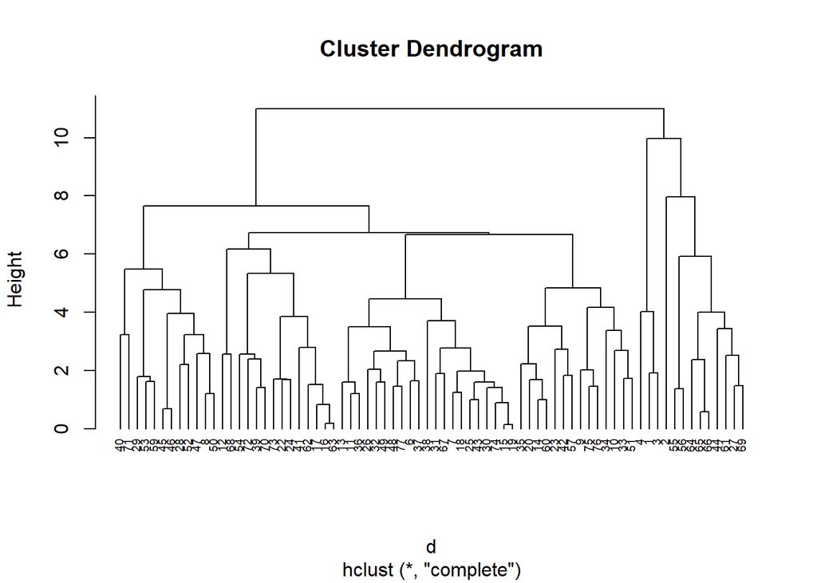

```r
plot(hc1_complete, cex = 0.6, hang = -1)
```

Clustering can also be done with the agnes() method. The sole contrast between agnes() and hclust() is that agnes includes an agglomerative coefficient. This coefficient shows if the clustering structure is robust or weak.

Performing clustering using agnes() with single, complete, average and ward.

```r
hc_single <- agnes(data_df_scaled, method = "single")
hc_complete <- agnes(data_df_scaled, method = "complete")
hc_average <- agnes(data_df_scaled, method = "average")
hc_ward <- agnes(data_df_scaled, method = "ward")
```

In Hierarchical clustering we have ward.D and ward.D2. The only difference between ward. D & ward. D2 is the input parameter. The Ward2 criterion values are “on a scale of distances” whereas the Ward1 criterion values are “on a scale of distances squared. Now we will compare the agglomerative coefficients

For Single

```r
print(hc_single$ac)
```

```
## [1] 0.6067859
```

For complete

```r
print(hc_complete$ac)
```

```
## [1] 0.8353712
```

For average

```r
print(hc_average$ac)
```

```
## [1] 0.7766075
```

For Ward

```r
print(hc_ward$ac)
```

```
## [1] 0.9046042
```

results indicate that wards is the best method with 0.904

now we are going to plot agnes with wards method and cut the dendogram. we are going to take k=4, keeping distance in mind.

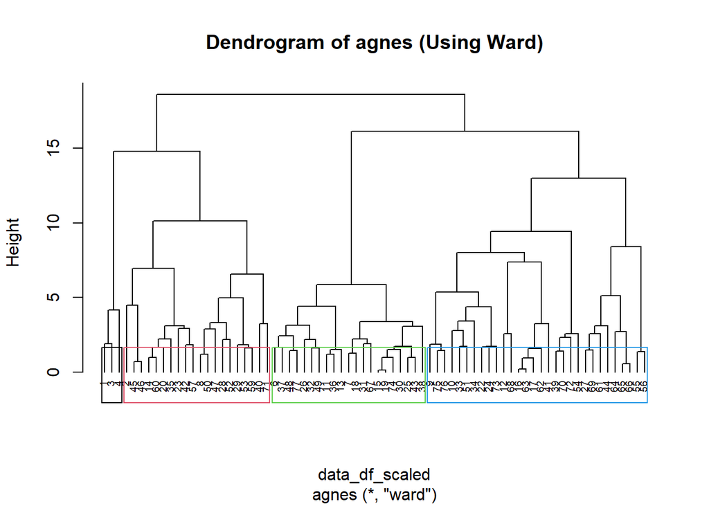

```r
pltree(hc_ward, cex = 0.6, hang = -1, main = "Dendrogram of agnes (Using Ward)")
rect.hclust(hc_ward, k = 4, border = 1:4)
```

```r
cluster1 <- cutree(hc_ward, k=4)
df2 <- as.data.frame(cbind(data_df_scaled,cluster1))
```

creating partition

```r
part_1 <- data_df[1:55,]
part_2 <- data_df[56:74,]
```

now we are going toPerforming Hierarichal Clustering, plotting dendogram and then cutting the dendogram by taking k = 4.

```r
agnes_ward <- agnes(scale(part_1), method = "ward")
agnes_average <- agnes(scale(part_1), method = "average")
agnes_complete <- agnes(scale(part_1), method = "complete")
agnes_single <- agnes(scale(part_1), method = "single")

cbind(ward=agnes_ward$ac, average=agnes_average$ac, complete=agnes_complete$ac,
      single=agnes_single$ac)
```

```
##           ward   average  complete    single
## [1,] 0.8808195 0.7449303 0.8120228 0.6564842
```

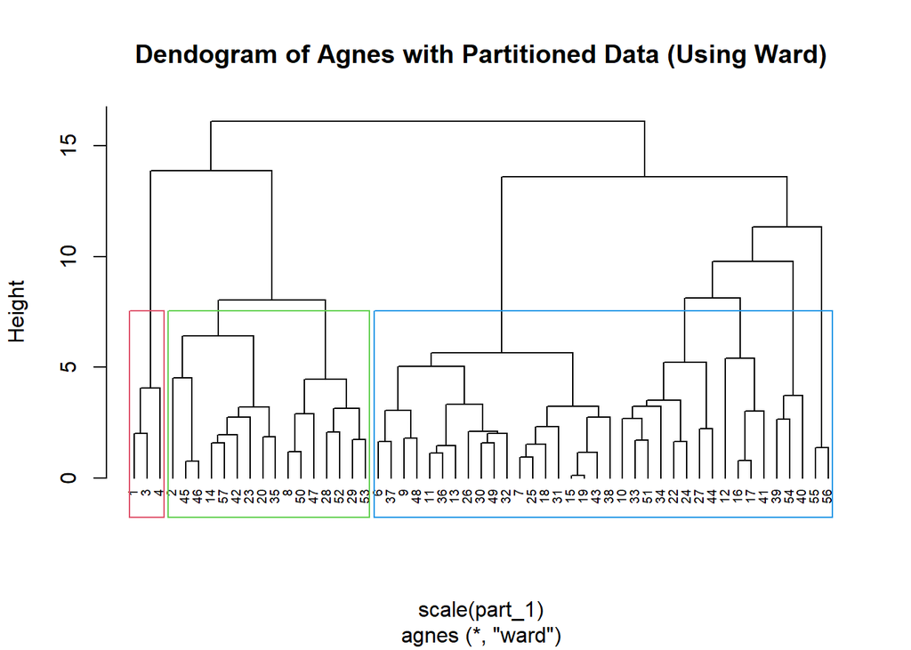

```r
pltree(agnes_ward, cex = 0.6, hang = -1, main = "Dendogram of Agnes with Partitioned Data (Using Ward)")
rect.hclust(agnes_ward, k = 3, border = 2:5)
```

```r
cut_2 <- cutree(agnes_ward, k = 4)
```

in the following step we are going to calculate centers.

```r
result <- as.data.frame(cbind(part_1, cut_2))
result[result$cut_2==1,]
```

|  | calories | protein | fat | sodium | fiber | carbo | sugars | potass | vitamins | shelf | weight | cups | rating | cut_2 |
| --- | --- | --- | --- | --- | --- | --- | --- | --- | --- | --- | --- | --- | --- | --- |
| 1 | 70 | 4 | 1 | 130 | 10 | 5 | 6 | 280 | 25 | 3 | 1 | 0.33 | 68.40297 | 1 |
| 3 | 70 | 4 | 1 | 260 | 9 | 7 | 5 | 320 | 25 | 3 | 1 | 0.33 | 59.42551 | 1 |
| 4 | 50 | 4 | 0 | 140 | 14 | 8 | 0 | 330 | 25 | 3 | 1 | 0.50 | 93.70491 | 1 |

```r
center1 <- colMeans(result[result$cut_2==1,])

result[result$cut_2==2,]
```

|  | calories | protein | fat | sodium | fiber | carbo | sugars | potass | vitamins | shelf | weight | cups | rating | cut_2 |
| --- | --- | --- | --- | --- | --- | --- | --- | --- | --- | --- | --- | --- | --- | --- |
| 2 | 120 | 3 | 5 | 15 | 2.0 | 8.0 | 8 | 135 | 0 | 3 | 1.00 | 1.00 | 33.98368 | 2 |
| 8 | 130 | 3 | 2 | 210 | 2.0 | 18.0 | 8 | 100 | 25 | 3 | 1.33 | 0.75 | 37.03856 | 2 |
| 14 | 110 | 3 | 2 | 140 | 2.0 | 13.0 | 7 | 105 | 25 | 3 | 1.00 | 0.50 | 40.40021 | 2 |
| 20 | 110 | 3 | 3 | 140 | 4.0 | 10.0 | 7 | 160 | 25 | 3 | 1.00 | 0.50 | 40.44877 | 2 |
| 23 | 100 | 2 | 1 | 140 | 2.0 | 11.0 | 10 | 120 | 25 | 3 | 1.00 | 0.75 | 36.17620 | 2 |
| 28 | 120 | 3 | 2 | 160 | 5.0 | 12.0 | 10 | 200 | 25 | 3 | 1.25 | 0.67 | 40.91705 | 2 |
| 29 | 120 | 3 | 0 | 240 | 5.0 | 14.0 | 12 | 190 | 25 | 3 | 1.33 | 0.67 | 41.01549 | 2 |
| 35 | 120 | 3 | 3 | 75 | 3.0 | 13.0 | 4 | 100 | 25 | 3 | 1.00 | 0.33 | 45.81172 | 2 |
| 42 | 100 | 4 | 2 | 150 | 2.0 | 12.0 | 6 | 95 | 25 | 2 | 1.00 | 0.67 | 45.32807 | 2 |
| 45 | 150 | 4 | 3 | 95 | 3.0 | 16.0 | 11 | 170 | 25 | 3 | 1.00 | 1.00 | 37.13686 | 2 |

[output cut: 6 more lines]

```r
center2 <- colMeans(result[result$cut_2==2,])

result[result$cut_2==3,]
```

|  | calories | protein | fat | sodium | fiber | carbo | sugars | potass | vitamins | shelf | weight | cups | rating | cut_2 |
| --- | --- | --- | --- | --- | --- | --- | --- | --- | --- | --- | --- | --- | --- | --- |
| 6 | 110 | 2 | 2 | 180 | 1.5 | 10.5 | 10 | 70 | 25 | 1 | 1 | 0.75 | 29.50954 | 3 |
| 7 | 110 | 2 | 0 | 125 | 1.0 | 11.0 | 14 | 30 | 25 | 2 | 1 | 1.00 | 33.17409 | 3 |
| 9 | 90 | 2 | 1 | 200 | 4.0 | 15.0 | 6 | 125 | 25 | 1 | 1 | 0.67 | 49.12025 | 3 |
| 11 | 120 | 1 | 2 | 220 | 0.0 | 12.0 | 12 | 35 | 25 | 2 | 1 | 0.75 | 18.04285 | 3 |
| 13 | 120 | 1 | 3 | 210 | 0.0 | 13.0 | 9 | 45 | 25 | 2 | 1 | 0.75 | 19.82357 | 3 |
| 15 | 110 | 1 | 1 | 180 | 0.0 | 12.0 | 13 | 55 | 25 | 2 | 1 | 1.00 | 22.73645 | 3 |
| 18 | 110 | 1 | 0 | 90 | 1.0 | 13.0 | 12 | 20 | 25 | 2 | 1 | 1.00 | 35.78279 | 3 |
| 19 | 110 | 1 | 1 | 180 | 0.0 | 12.0 | 13 | 65 | 25 | 2 | 1 | 1.00 | 22.39651 | 3 |
| 25 | 110 | 2 | 1 | 125 | 1.0 | 11.0 | 13 | 30 | 25 | 2 | 1 | 1.00 | 32.20758 | 3 |
| 26 | 110 | 1 | 0 | 200 | 1.0 | 14.0 | 11 | 25 | 25 | 1 | 1 | 0.75 | 31.43597 | 3 |

[output cut: 9 more lines]

```r
center3 <- colMeans(result[result$cut_2==3,])

result[result$cut_2==4,]
```

|  | calories | protein | fat | sodium | fiber | carbo | sugars | potass | vitamins | shelf | weight | cups | rating | cut_2 |
| --- | --- | --- | --- | --- | --- | --- | --- | --- | --- | --- | --- | --- | --- | --- |
| 10 | 90 | 3 | 0 | 210 | 5 | 13 | 5 | 190 | 25 | 3 | 1.0 | 0.67 | 53.31381 | 4 |
| 12 | 110 | 6 | 2 | 290 | 2 | 17 | 1 | 105 | 25 | 1 | 1.0 | 1.25 | 50.76500 | 4 |
| 16 | 110 | 2 | 0 | 280 | 0 | 22 | 3 | 25 | 25 | 1 | 1.0 | 1.00 | 41.44502 | 4 |
| 17 | 100 | 2 | 0 | 290 | 1 | 21 | 2 | 35 | 25 | 1 | 1.0 | 1.00 | 45.86332 | 4 |
| 22 | 110 | 2 | 0 | 220 | 1 | 21 | 3 | 30 | 25 | 3 | 1.0 | 1.00 | 46.89564 | 4 |
| 24 | 100 | 2 | 0 | 190 | 1 | 18 | 5 | 80 | 25 | 3 | 1.0 | 0.75 | 44.33086 | 4 |
| 27 | 100 | 3 | 0 | 0 | 3 | 14 | 7 | 100 | 25 | 2 | 1.0 | 0.80 | 58.34514 | 4 |
| 33 | 100 | 3 | 1 | 140 | 3 | 15 | 5 | 85 | 25 | 3 | 1.0 | 0.88 | 52.07690 | 4 |
| 34 | 110 | 3 | 0 | 170 | 3 | 17 | 3 | 90 | 25 | 3 | 1.0 | 0.25 | 53.37101 | 4 |
| 39 | 110 | 2 | 1 | 170 | 1 | 17 | 6 | 60 | 100 | 3 | 1.0 | 1.00 | 36.52368 | 4 |

[output cut: 7 more lines]

```r
center4 <- colMeans(result[result$cut_2==4,])

centers <- rbind(center1, center2, center3, center4)

x2 <- as.data.frame(rbind(centers[,-14], part_2))
```

in the following step we are going to calculate distence.

```r
d1 <- get_dist(x2)

mat1 <- as.matrix(d1)

df1 <- data.frame(data=seq(1,nrow(part_2),1), clusters = rep(0,nrow(part_2)))

for(i in 1:nrow(part_2)) {

  df1[i,2] <- which.min(mat1[i+4, 1:4])
}
df1
```

| data | clusters |
| --- | --- |
| 1 | 1 |
| 2 | 2 |
| 3 | 2 |
| 4 | 3 |
| 5 | 3 |
| 6 | 2 |
| 7 | 2 |
| 8 | 2 |
| 9 | 4 |
| 10 | 3 |

[output cut: 9 more lines]

```r
cbind(df2$cluster1[56:74], df1$clusters)
```

```
##       [,1] [,2]
##  [1,]    2    1
##  [2,]    2    2
##  [3,]    4    2
##  [4,]    4    3
##  [5,]    4    3
##  [6,]    4    2
##  [7,]    4    2
##  [8,]    4    2
##  [9,]    3    4
## [10,]    4    3
## [11,]    4    2
## [12,]    4    3
## [13,]    2    2
## [14,]    4    4
## [15,]    4    3
## [16,]    3    3
## [17,]    4    4
## [18,]    4    4
## [19,]    3    3
```

```r
table(df2$cluster1[56:74] == df1$clusters)
```

```
##
## FALSE  TRUE
##    12     7
```

now we can conclude that this model is not stable as 12 out of 19 are false.

now we are going to cluster of healthy cereals.

```r
new_data <- Cereals
new_data_na <- na.omit(new_data)

Clust <- cbind(new_data_na, cluster1)

Clust[Clust$cluster1==1,]
```

|  | name | mfr | type | calories | protein | fat | sodium | fiber | carbo | sugars | potass | vitamins | shelf | weight | cups | rating | cluster1 |
| --- | --- | --- | --- | --- | --- | --- | --- | --- | --- | --- | --- | --- | --- | --- | --- | --- | --- |
| 1 | 100%_Bran | N | C | 70 | 4 | 1 | 130 | 10 | 5 | 6 | 280 | 25 | 3 | 1 | 0.33 | 68.40297 | 1 |
| 3 | All-Bran | K | C | 70 | 4 | 1 | 260 | 9 | 7 | 5 | 320 | 25 | 3 | 1 | 0.33 | 59.42551 | 1 |
| 4 | All-Bran_with_Extra_Fiber | K | C | 50 | 4 | 0 | 140 | 14 | 8 | 0 | 330 | 25 | 3 | 1 | 0.50 | 93.70491 | 1 |

```r
Clust[Clust$cluster1==2,]
```

|  | name | mfr | type | calories | protein | fat | sodium | fiber | carbo | sugars | potass | vitamins | shelf | weight | cups | rating | cluster1 |
| --- | --- | --- | --- | --- | --- | --- | --- | --- | --- | --- | --- | --- | --- | --- | --- | --- | --- |
| 2 | 100%_Natural_Bran | Q | C | 120 | 3 | 5 | 15 | 2.0 | 8.0 | 8 | 135 | 0 | 3 | 1.00 | 1.00 | 33.98368 | 2 |
| 8 | Basic_4 | G | C | 130 | 3 | 2 | 210 | 2.0 | 18.0 | 8 | 100 | 25 | 3 | 1.33 | 0.75 | 37.03856 | 2 |
| 14 | Clusters | G | C | 110 | 3 | 2 | 140 | 2.0 | 13.0 | 7 | 105 | 25 | 3 | 1.00 | 0.50 | 40.40021 | 2 |
| 20 | Cracklin'_Oat_Bran | K | C | 110 | 3 | 3 | 140 | 4.0 | 10.0 | 7 | 160 | 25 | 3 | 1.00 | 0.50 | 40.44877 | 2 |
| 23 | Crispy_Wheat_&_Raisins | G | C | 100 | 2 | 1 | 140 | 2.0 | 11.0 | 10 | 120 | 25 | 3 | 1.00 | 0.75 | 36.17620 | 2 |
| 28 | Fruit_&_Fibre_Dates,_Walnuts,_and_Oats | P | C | 120 | 3 | 2 | 160 | 5.0 | 12.0 | 10 | 200 | 25 | 3 | 1.25 | 0.67 | 40.91705 | 2 |
| 29 | Fruitful_Bran | K | C | 120 | 3 | 0 | 240 | 5.0 | 14.0 | 12 | 190 | 25 | 3 | 1.33 | 0.67 | 41.01549 | 2 |
| 35 | Great_Grains_Pecan | P | C | 120 | 3 | 3 | 75 | 3.0 | 13.0 | 4 | 100 | 25 | 3 | 1.00 | 0.33 | 45.81172 | 2 |
| 40 | Just_Right_Fruit_&_Nut | K | C | 140 | 3 | 1 | 170 | 2.0 | 20.0 | 9 | 95 | 100 | 3 | 1.30 | 0.75 | 36.47151 | 2 |
| 42 | Life | Q | C | 100 | 4 | 2 | 150 | 2.0 | 12.0 | 6 | 95 | 25 | 2 | 1.00 | 0.67 | 45.32807 | 2 |

[output cut: 10 more lines]

```r
Clust[Clust$cluster1==3,]
```

|  | name | mfr | type | calories | protein | fat | sodium | fiber | carbo | sugars | potass | vitamins | shelf | weight | cups | rating | cluster1 |
| --- | --- | --- | --- | --- | --- | --- | --- | --- | --- | --- | --- | --- | --- | --- | --- | --- | --- |
| 6 | Apple_Cinnamon_Cheerios | G | C | 110 | 2 | 2 | 180 | 1.5 | 10.5 | 10 | 70 | 25 | 1 | 1 | 0.75 | 29.50954 | 3 |
| 7 | Apple_Jacks | K | C | 110 | 2 | 0 | 125 | 1.0 | 11.0 | 14 | 30 | 25 | 2 | 1 | 1.00 | 33.17409 | 3 |
| 11 | Cap'n'Crunch | Q | C | 120 | 1 | 2 | 220 | 0.0 | 12.0 | 12 | 35 | 25 | 2 | 1 | 0.75 | 18.04285 | 3 |
| 13 | Cinnamon_Toast_Crunch | G | C | 120 | 1 | 3 | 210 | 0.0 | 13.0 | 9 | 45 | 25 | 2 | 1 | 0.75 | 19.82357 | 3 |
| 15 | Cocoa_Puffs | G | C | 110 | 1 | 1 | 180 | 0.0 | 12.0 | 13 | 55 | 25 | 2 | 1 | 1.00 | 22.73645 | 3 |
| 18 | Corn_Pops | K | C | 110 | 1 | 0 | 90 | 1.0 | 13.0 | 12 | 20 | 25 | 2 | 1 | 1.00 | 35.78279 | 3 |
| 19 | Count_Chocula | G | C | 110 | 1 | 1 | 180 | 0.0 | 12.0 | 13 | 65 | 25 | 2 | 1 | 1.00 | 22.39651 | 3 |
| 25 | Froot_Loops | K | C | 110 | 2 | 1 | 125 | 1.0 | 11.0 | 13 | 30 | 25 | 2 | 1 | 1.00 | 32.20758 | 3 |
| 26 | Frosted_Flakes | K | C | 110 | 1 | 0 | 200 | 1.0 | 14.0 | 11 | 25 | 25 | 1 | 1 | 0.75 | 31.43597 | 3 |
| 30 | Fruity_Pebbles | P | C | 110 | 1 | 1 | 135 | 0.0 | 13.0 | 12 | 25 | 25 | 2 | 1 | 0.75 | 28.02576 | 3 |

[output cut: 11 more lines]

```r
Clust[Clust$cluster1==4,]
```

|  | name | mfr | type | calories | protein | fat | sodium | fiber | carbo | sugars | potass | vitamins | shelf | weight | cups | rating | cluster1 |
| --- | --- | --- | --- | --- | --- | --- | --- | --- | --- | --- | --- | --- | --- | --- | --- | --- | --- |
| 9 | Bran_Chex | R | C | 90 | 2 | 1 | 200 | 4 | 15 | 6 | 125 | 25 | 1 | 1.00 | 0.67 | 49.12025 | 4 |
| 10 | Bran_Flakes | P | C | 90 | 3 | 0 | 210 | 5 | 13 | 5 | 190 | 25 | 3 | 1.00 | 0.67 | 53.31381 | 4 |
| 12 | Cheerios | G | C | 110 | 6 | 2 | 290 | 2 | 17 | 1 | 105 | 25 | 1 | 1.00 | 1.25 | 50.76500 | 4 |
| 16 | Corn_Chex | R | C | 110 | 2 | 0 | 280 | 0 | 22 | 3 | 25 | 25 | 1 | 1.00 | 1.00 | 41.44502 | 4 |
| 17 | Corn_Flakes | K | C | 100 | 2 | 0 | 290 | 1 | 21 | 2 | 35 | 25 | 1 | 1.00 | 1.00 | 45.86332 | 4 |
| 22 | Crispix | K | C | 110 | 2 | 0 | 220 | 1 | 21 | 3 | 30 | 25 | 3 | 1.00 | 1.00 | 46.89564 | 4 |
| 24 | Double_Chex | R | C | 100 | 2 | 0 | 190 | 1 | 18 | 5 | 80 | 25 | 3 | 1.00 | 0.75 | 44.33086 | 4 |
| 27 | Frosted_Mini-Wheats | K | C | 100 | 3 | 0 | 0 | 3 | 14 | 7 | 100 | 25 | 2 | 1.00 | 0.80 | 58.34514 | 4 |
| 33 | Grape_Nuts_Flakes | P | C | 100 | 3 | 1 | 140 | 3 | 15 | 5 | 85 | 25 | 3 | 1.00 | 0.88 | 52.07690 | 4 |
| 34 | Grape-Nuts | P | C | 110 | 3 | 0 | 170 | 3 | 17 | 3 | 90 | 25 | 3 | 1.00 | 0.25 | 53.37101 | 4 |

[output cut: 20 more lines]

now we are going to calculate mean rating so that we can find out the best cereal.

```r
mean(Clust[Clust$cluster1==1,"rating"])
```

```
## [1] 73.84446
```

```r
mean(Clust[Clust$cluster1==2,"rating"])
```

```
## [1] 38.26161
```

```r
mean(Clust[Clust$cluster1==3,"rating"])
```

```
## [1] 28.84825
```

```r
mean(Clust[Clust$cluster1==4,"rating"])
```

```
## [1] 51.43111
```

from the above readings we can conclude that cluster 1 is the best cereal as it has highest rating.